# 2022 World Cup

## 2022 World Cup: An Event-Level Football Analytics Using StatsBomb Open Data

### Introduction

The 2022 FIFA World Cup in Qatar brought together 32 national teams competing at the highest level of international football, generating rich event-level data that captures tactical decisions, player actions, and match dynamics.

This project analyzes the tournament using StatsBomb Open Data, applying modern data science and football analytics techniques to study passes, shots, defensive actions, and team structures. Through pitch-based visualizations built with mplsoccer, the analysis transforms complex football data into clear, interpretable insights aligned with professional broadcast and club-level analysis standards.

### Aims & Objectives

Primary Aim:

To conduct a comprehensive, data-driven analysis of the 2022 FIFA World Cup using event-level data, revealing tactical patterns, performance metrics, and strategic insights across both tournament-wide and match-specific contexts.

Objectives:

- Analyze tactical formations, expected goals (xG) accumulation, shot quality and player positioning between finalists, Argentina and France
- Identify top-performing teams, players across key metrics (goals, xG, possession, assist, passing).
- Determine optimal scoring periods and vulnerability windows across matches.
- Evaluate set-piece effectiveness vs open play goal distribution.
- Create broadcast-quality visualizations insights matching professional analytics standards.

### Load 2022 World Cup Data

```python
# Import required libraries

from statsbombpy import sb
import pandas as pd
import numpy as np
from mplsoccer import Pitch
import matplotlib.pyplot as plt
```

Get competitions

```python
competitions = sb.competitions()
```

Filter World Cup 2022

```python
wc_2022 = competitions[
    (competitions["competition_name"] == "FIFA World Cup") &
    (competitions["season_name"] == "2022")
]
```

Load matches

```python
matches = sb.matches(
    competition_id=wc_2022.iloc[0]["competition_id"],
    season_id=wc_2022.iloc[0]["season_id"]
)
```

Pick one match:

```python
match_id = matches.iloc[0]["match_id"]
```

Load Event Level Data

```python
events = sb.events(match_id=match_id)
```

### Argentina VS France Final Match Analysis

```python
# Load Argentina vs France final
argentina_match_id = 3869685  # The World Cup final!
```

```python
# Load events for that match
events = sb.events(match_id=argentina_match_id)
```

```python
# Filter for Argentina events only
argentina_events = events[events['team'] == 'Argentina'].copy()
```

```python
# Calculate average positions per player
# Only include events that have location data
argentina_with_location = argentina_events[argentina_events['location'].notna()].copy()

avg_positions = argentina_with_location.groupby('player').agg({
    'location': list
}).reset_index()
```

```python
# Calculate average x and y positions for Argentina

avg_positions['avg_x'] = avg_positions['location'].apply(
    lambda locs: sum([loc[0] for loc in locs]) / len(locs) if locs else 0
)
avg_positions['avg_y'] = avg_positions['location'].apply(
    lambda locs: sum([loc[1] for loc in locs]) / len(locs) if locs else 0
)
avg_positions['actions'] = avg_positions['location'].apply(len)
avg_positions['team'] = 'Argentina'
```

```python
# filter for Argentina
argentina = avg_positions[avg_positions["team"] == "Argentina"].copy()
```

```python
print(f"Found {len(argentina)} Argentina players")
print(argentina[['player', 'avg_x', 'avg_y', 'actions']].head(10))
```

```
Found 17 Argentina players
                           player      avg_x      avg_y  actions
0             Alexis Mac Allister  65.755897  24.585128      195
1         Cristian Gabriel Romero  33.388670  51.943842      203
2        Damián Emiliano Martínez   9.812346  42.340741       81
3                  Enzo Fernandez  53.426220  43.403354      328
4       Germán Alejandro Pezzella  53.300000  30.666667        3
5           Gonzalo Ariel Montiel  60.761818  68.527273       55
6                  Julián Álvarez  76.200680  40.263265      147
7         Lautaro Javier Martínez  93.835294  35.997059       34
8          Leandro Daniel Paredes  51.535556  42.988889       45
9  Lionel Andrés Messi Cuccittini  76.269038  51.536820      239
```

```python
# Fix Messi's name display
argentina.loc[argentina['player'].str.contains('Messi', case=False), 'display_name'] = 'Messi'
```

```python
# For all other players, use last name
argentina.loc[argentina['display_name'].isna(), 'display_name'] = argentina.loc[argentina['display_name'].isna(), 'player'].apply(lambda x: x.split()[-1])
```

```python
# Filter for France events from the same match
france_events = events[events['team'] == 'France'].copy()
```

```python
# Calculate average positions per player
# Only include events that have location data
france_with_location = france_events[france_events['location'].notna()].copy()

avg_positions_france = france_with_location.groupby('player').agg({
    'location': list
}).reset_index()
```

```python
# Calculate average x and y positions for France

avg_positions_france['avg_x'] = avg_positions_france['location'].apply(
    lambda locs: sum([loc[0] for loc in locs]) / len(locs) if locs else 0
)
avg_positions_france['avg_y'] = avg_positions_france['location'].apply(
    lambda locs: sum([loc[1] for loc in locs]) / len(locs) if locs else 0
)
avg_positions_france['actions'] = avg_positions_france['location'].apply(len)
avg_positions_france['team'] = 'France'
```

```python
# Filter for France
france = avg_positions_france[avg_positions_france["team"] == "France"].copy()

print(f"Found {len(france)} France players")
print(france[['player', 'avg_x', 'avg_y', 'actions']])
```

```
Found 17 France players
                             player      avg_x      avg_y  actions
0                     Adrien Rabiot  62.047126  26.544828      174
1                 Antoine Griezmann  63.973529  43.860784      102
2         Aurélien Djani Tchouaméni  60.119512  39.119024      205
3          Dayotchanculle Upamecano  44.557576  26.196465      198
4                 Eduardo Camavinga  49.175904  11.893976       83
5                       Hugo Lloris  10.190625  38.872917       96
6                   Ibrahima Konaté  64.700000  54.172727       11
7                      Jules Koundé  51.271429  67.521905      210
8                    Kingsley Coman  65.895294  57.614118       85
9              Kylian Mbappé Lottin  83.687919  18.302685      149
10                    Marcus Thuram  68.993277  17.086555      119
11                   Olivier Giroud  72.702941  43.985294       34
12                  Ousmane Dembélé  65.325490  69.470588       51
13                Randal Kolo Muani  78.645669  49.825197      127
14                   Raphaël Varane  43.250829  50.269061      181
15  Theo Bernard François Hernández  62.384615   8.016084      143
16                  Youssouf Fofana  66.204878  26.800000       41
```

```python
# Fix special player names if needed (e.g., Mbappé)

france['display_name'] = france['player'].apply(lambda x: x.split()[-1])
```

```python
france.loc[france['player'].str.contains('Mbappé', case=False), 'display_name'] = 'Mbappé'
```

### Visualizing Average Player Positions : Argentina VS France Final

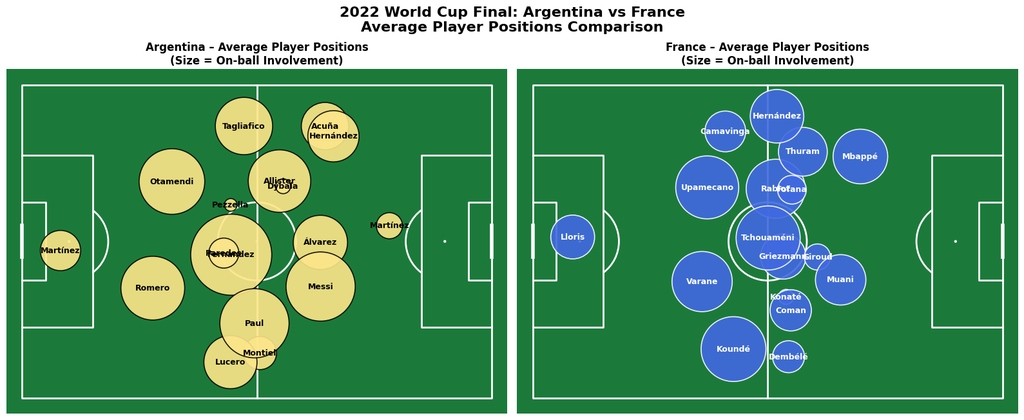

```python
from mplsoccer import Pitch
import matplotlib.pyplot as plt

# Create side-by-side pitches
pitch = Pitch(
    pitch_type="statsbomb",
    pitch_color="#1b7a3a",
    line_color="white"
)

fig, axes = plt.subplots(1, 2, figsize=(16, 7))

# ==== ARGENTINA (Left) ====
pitch.draw(ax=axes[0])

argentina["size"] = argentina["actions"] * 25
argentina.loc[argentina["size"] < 200, "size"] = 200

pitch.scatter(
    argentina["avg_x"],
    argentina["avg_y"],
    s=argentina["size"],
    color="#fde68a",
    edgecolors="black",
    linewidth=1.2,
    alpha=0.9,
    ax=axes[0]
)

for _, row in argentina.iterrows():
    axes[0].text(
        row["avg_x"],
        row["avg_y"],
        row["display_name"],
        ha="center",
        va="center",
        fontsize=9,
        weight="bold"
    )

axes[0].set_title(
    "Argentina – Average Player Positions\n(Size = On-ball Involvement)",
    fontsize=12,
    weight="bold"
)

# ==== FRANCE (Right) ====
pitch.draw(ax=axes[1])

france["size"] = france["actions"] * 25
france.loc[france["size"] < 200, "size"] = 200

pitch.scatter(
    france["avg_x"],
    france["avg_y"],
    s=france["size"],
    color="#4169E1",
    edgecolors="white",
    linewidth=1.2,
    alpha=0.9,
    ax=axes[1]
)

for _, row in france.iterrows():
    axes[1].text(
        row["avg_x"],
        row["avg_y"],
        row["display_name"],
        ha="center",
        va="center",
        fontsize=9,
        weight="bold",
        color="white"
    )

axes[1].set_title(
    "France – Average Player Positions\n(Size = On-ball Involvement)",
    fontsize=12,
    weight="bold"
)

# Overall title
fig.suptitle(
    "2022 World Cup Final: Argentina vs France\nAverage Player Positions Comparison",
    fontsize=16,
    weight="bold",
    y=0.98
)

plt.tight_layout()
plt.show()
```

Insights:

Argentina:

- Argentina maintained a balanced 4-3-3 formation with Messi operating high and wide on the right flank, indicating an attacking setup focused on utilizing his creativity.
- The midfield trio (Fernández, Mac Allister, De Paul) positioned centrally shows Argentina's emphasis on controlling the middle of the pitch and building attacks through the center.

France:

- France adopted a more compact 4-2-3-1 formation with Mbappé positioned high and wide, mirroring Messi's role but on the opposite flank.
- The deeper positioning of Tchouaméni and Rabiot as a double pivot indicates France's focus on defensive stability and counter-attacking opportunities.

### Pass Networks - Argentina VS France

What Were the Key Differences in Passing Patterns Between Argentina and France?

```python
# Analyzing Pass Networks
def get_pass_network(events_df, team_name, min_passes=3):
    """Calculate pass network for a team"""
    team_events = events_df[(events_df['team'] == team_name) & (events_df['location'].notna())]

    # Average positions
    positions = team_events.groupby('player')['location'].apply(
        lambda x: [np.mean([loc[0] for loc in x]), np.mean([loc[1] for loc in x]), len(x)]
    ).reset_index()
    positions[['avg_x', 'avg_y', 'num_events']] = pd.DataFrame(positions['location'].tolist(), index=positions.index)

    # Pass connections
    passes = events_df[(events_df['team'] == team_name) & (events_df['type'] == 'Pass')]
    connections = passes.groupby(['player', 'pass_recipient']).size().reset_index(name='count')
    connections = connections[connections['count'] >= min_passes]

    # Merge positions
    connections = connections.merge(positions[['player', 'avg_x', 'avg_y']], on='player')
    connections = connections.merge(positions[['player', 'avg_x', 'avg_y']],
                                   left_on='pass_recipient', right_on='player',
                                   suffixes=('_from', '_to'))

    return positions.nlargest(11, 'num_events'), connections

argentina_pos, argentina_conn = get_pass_network(events, 'Argentina')
france_pos, france_conn = get_pass_network(events, 'France')
```

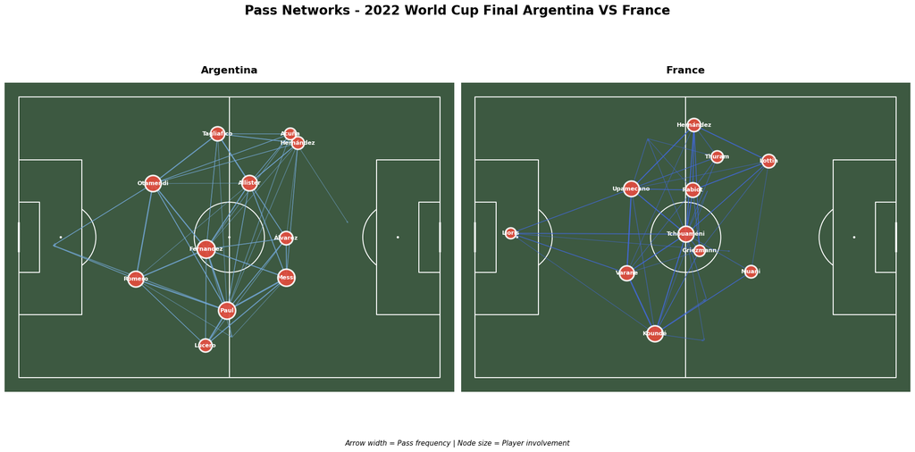

```python
# Visualize Side-by-Side

pitch = Pitch(pitch_type="statsbomb", pitch_color="#3d5941", line_color="white", linewidth=1.5)
fig, axes = plt.subplots(1, 2, figsize=(20, 10), facecolor='white')
fig.suptitle('Pass Networks - 2022 World Cup Final Argentina VS France', fontsize=20, weight='bold', y=0.98)

for ax, positions, connections, team, color in zip(
    axes,
    [argentina_pos, france_pos],
    [argentina_conn, france_conn],
    ['Argentina', 'France'],
    ['#75AADB', '#4169E1']
):
    pitch.draw(ax=ax)

    # Pass arrows
    for _, row in connections.iterrows():
        pitch.arrows(row['avg_x_from'], row['avg_y_from'], row['avg_x_to'], row['avg_y_to'],
                    width=np.sqrt(row['count'])*0.5, headwidth=3, headlength=3,
                    color=color, alpha=0.6, ax=ax, zorder=1)

    # Player nodes
    node_sizes = np.clip(positions['num_events']*3, 200, 800)
    pitch.scatter(positions['avg_x'], positions['avg_y'], s=node_sizes,
                 color='#E74C3C', edgecolors='white', linewidth=2.5,
                 alpha=0.9, ax=ax, zorder=3)

    # Labels
    for _, player in positions.iterrows():
        label = 'Messi' if 'Messi' in player['player'] else player['player'].split()[-1]
        ax.text(player['avg_x'], player['avg_y'], label, fontsize=9, weight='bold',
               ha='center', va='center', color='white', zorder=4)

    ax.set_title(team, fontsize=16, weight='bold', pad=15)

fig.text(0.5, 0.02, "Arrow width = Pass frequency | Node size = Player involvement",
         ha='center', fontsize=11, style='italic')

plt.tight_layout(rect=[0, 0.03, 1, 0.96])
plt.show()
```

### Key Player Analysis

Messi and Mbappe

```python
# Extract Messi and Mbappé Data

# Filter shots for both players
messi_shots = events[
    (events['player'].str.contains('Messi', case=False, na=False)) &
    (events['type'] == 'Shot')
].copy()

mbappe_shots = events[
    (events['player'].str.contains('Mbappé', case=False, na=False)) &
    (events['type'] == 'Shot')
].copy()
```

```python
# Extract location data

messi_shots['x'] = messi_shots['location'].str[0]
messi_shots['y'] = messi_shots['location'].str[1]
messi_shots['xg'] = messi_shots['shot_statsbomb_xg']
messi_shots['goal'] = messi_shots['shot_outcome'] == 'Goal'

mbappe_shots['x'] = mbappe_shots['location'].str[0]
mbappe_shots['y'] = mbappe_shots['location'].str[1]
mbappe_shots['xg'] = mbappe_shots['shot_statsbomb_xg']
mbappe_shots['goal'] = mbappe_shots['shot_outcome'] == 'Goal'
```

```python
# Calculate Key Metrics - Messi and Mbappe

# Messi metrics
messi_total_shots = len(messi_shots)
messi_total_xg = messi_shots['xg'].sum()
messi_xg_per_shot = messi_total_xg / messi_total_shots if messi_total_shots > 0 else 0
messi_goals = messi_shots['goal'].sum()

# Mbappé metrics
mbappe_total_shots = len(mbappe_shots)
mbappe_total_xg = mbappe_shots['xg'].sum()
mbappe_xg_per_shot = mbappe_total_xg / mbappe_total_shots if mbappe_total_shots > 0 else 0
mbappe_goals = mbappe_shots['goal'].sum()
```

```python
# Assists (that's pass events that led to goals)
messi_assists = events[
    (events['player'].str.contains('Messi', case=False, na=False)) &
    (events['pass_goal_assist'] == True)
].shape[0]

mbappe_assists = events[
    (events['player'].str.contains('Mbappé', case=False, na=False)) &
    (events['pass_goal_assist'] == True)
].shape[0]

print("=" * 50)
print("MESSI vs MBAPPÉ - 2022 WORLD CUP FINAL")
print("=" * 50)
print(f"\nLionel Messi:")
print(f"  Shots: {messi_total_shots}")
print(f"  Total xG: {messi_total_xg:.2f}")
print(f"  xG per shot: {messi_xg_per_shot:.3f}")
print(f"  Goals: {int(messi_goals)}")
print(f"  Assists: {messi_assists}")
print(f"  Goal Involvement: {int(messi_goals) + messi_assists}")

print(f"\nKylian Mbappé:")
print(f"  Shots: {mbappe_total_shots}")
print(f"  Total xG: {mbappe_total_xg:.2f}")
print(f"  xG per shot: {mbappe_xg_per_shot:.3f}")
print(f"  Goals: {int(mbappe_goals)}")
print(f"  Assists: {mbappe_assists}")
print(f"  Goal Involvement: {int(mbappe_goals) + mbappe_assists}")
print("=" * 50)
```

```
==================================================
MESSI vs MBAPPÉ - 2022 WORLD CUP FINAL
==================================================

Lionel Messi:
  Shots: 6
  Total xG: 2.24
  xG per shot: 0.373
  Goals: 3
  Assists: 0
  Goal Involvement: 3

Kylian Mbappé:
  Shots: 7
  Total xG: 2.57
  xG per shot: 0.367
  Goals: 4
  Assists: 0
  Goal Involvement: 4
==================================================
```

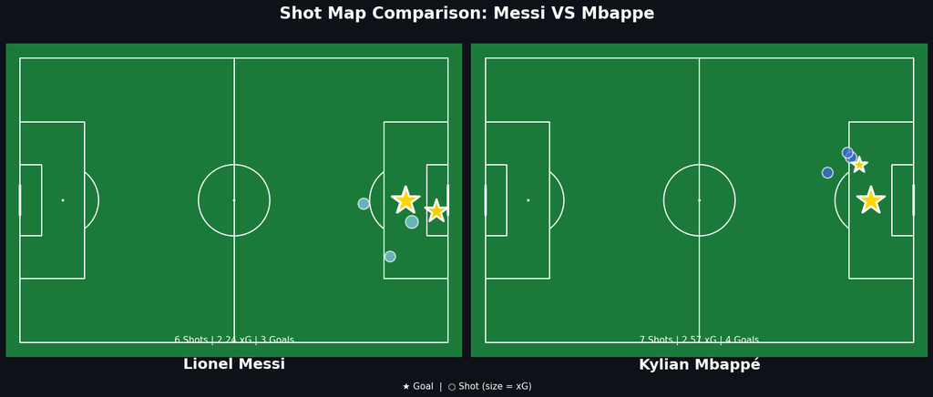

```python
# VISUALIZATION : Side-by-Side Shot Maps

pitch = Pitch(
    pitch_type="statsbomb",
    pitch_color="#1b7a3a",
    line_color="white",
    linewidth=1.5
)

fig, axes = plt.subplots(1, 2, figsize=(16, 7), facecolor='#0e1117')

# MESSI Shot Map
pitch.draw(ax=axes[0])

# Plot shots
for _, shot in messi_shots.iterrows():
    if shot['goal']:
        # Goals - larger, gold with star
        pitch.scatter(
            shot['x'], shot['y'],
            s=shot['xg'] * 1200 + 300,
            color='#FFD700',
            edgecolors='white',
            linewidth=2.5,
            alpha=0.95,
            ax=axes[0],
            zorder=3,
            marker='*'
        )
    else:
        # Non-goals
        pitch.scatter(
            shot['x'], shot['y'],
            s=shot['xg'] * 800 + 150,
            color='#87CEEB',
            edgecolors='white',
            linewidth=1.5,
            alpha=0.7,
            ax=axes[0],
            zorder=2
        )

axes[0].text(
    60, 84, 'Lionel Messi',
    fontsize=18, weight='bold', color='white',
    ha='center', va='top'
)
axes[0].text(
    60, 78,
    f'{messi_total_shots} Shots | {messi_total_xg:.2f} xG | {int(messi_goals)} Goals',
    fontsize=11, color='white', ha='center', va='top'
)

# MBAPPÉ Shot Map
pitch.draw(ax=axes[1])

# Plot shots
for _, shot in mbappe_shots.iterrows():
    if shot['goal']:
        # Goals - larger, gold with star
        pitch.scatter(
            shot['x'], shot['y'],
            s=shot['xg'] * 1200 + 300,
            color='#FFD700',
            edgecolors='white',
            linewidth=2.5,
            alpha=0.95,
            ax=axes[1],
            zorder=3,
            marker='*'
        )
    else:
        # Non-goals
        pitch.scatter(
            shot['x'], shot['y'],
            s=shot['xg'] * 800 + 150,
            color='#4169E1',
            edgecolors='white',
            linewidth=1.5,
            alpha=0.7,
            ax=axes[1],
            zorder=2
        )

axes[1].text(
    60, 84, 'Kylian Mbappé',
    fontsize=18, weight='bold', color='white',
    ha='center', va='top'
)
axes[1].text(
    60, 78,
    f'{mbappe_total_shots} Shots | {mbappe_total_xg:.2f} xG | {int(mbappe_goals)} Goals',
    fontsize=11, color='white', ha='center', va='top'
)

# Overall title
fig.text(
    0.5, 0.96,
    'Shot Map Comparison: Messi VS Mbappe',
    fontsize=20, weight='bold', color='white',
    ha='center', va='top'
)

# Legend
fig.text(
    0.5, 0.02,
    '★ Goal  |  ○ Shot (size = xG)',
    fontsize=11, color='white',
    ha='center', va='bottom'
)

plt.tight_layout(rect=[0, 0.03, 1, 0.94])
plt.show()
```

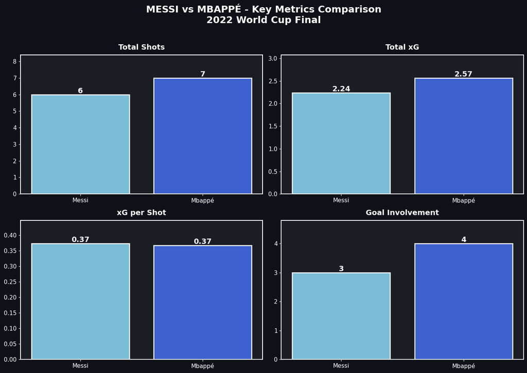

```python
# VISUALIZATION : Metrics Comparison Bar Chart - Messi Vs Mbappe

fig, axes = plt.subplots(2, 2, figsize=(14, 10), facecolor='#0e1117')
fig.suptitle(
    'MESSI vs MBAPPÉ - Key Metrics Comparison\n2022 World Cup Final',
    fontsize=18,
    weight='bold',
    color='white',
    y=0.98
)

metrics = [
    ('Total Shots', [messi_total_shots, mbappe_total_shots]),
    ('Total xG', [messi_total_xg, mbappe_total_xg]),
    ('xG per Shot', [messi_xg_per_shot, mbappe_xg_per_shot]),
    ('Goal Involvement', [int(messi_goals) + messi_assists, int(mbappe_goals) + mbappe_assists])
]

for idx, (ax, (metric_name, values)) in enumerate(zip(axes.flatten(), metrics)):
    ax.set_facecolor('#1a1d24')

    bars = ax.bar(
        ['Messi', 'Mbappé'],
        values,
        color=['#87CEEB', '#4169E1'],
        edgecolor='white',
        linewidth=2,
        alpha=0.9
    )

    # Add value labels on bars
    for bar, val in zip(bars, values):
        height = bar.get_height()
        ax.text(
            bar.get_x() + bar.get_width()/2.,
            height,
            f'{val:.2f}' if isinstance(val, float) else f'{val}',
            ha='center',
            va='bottom',
            fontsize=14,
            weight='bold',
            color='white'
        )

    ax.set_title(metric_name, fontsize=14, weight='bold', color='white', pad=10)
    ax.tick_params(colors='white', labelsize=11)
    ax.set_ylim(0, max(values) * 1.2)

    for spine in ax.spines.values():
        spine.set_edgecolor('white')
        spine.set_linewidth(1.5)

plt.tight_layout(rect=[0, 0, 1, 0.96])
plt.show()
```

### xG Timeline : Argentina VS France

Which Team Created Better Chances Throughout the Game?

```python
# Prepare Shot Data for Both Teams

# Get all shots from the final
final_shots = events[events['type'] == 'Shot'].copy()
```

```python
# Separate by team
argentina_shots = final_shots[final_shots['team'] == 'Argentina'].copy()
france_shots = final_shots[final_shots['team'] == 'France'].copy()

# Extract xG and minute data
argentina_shots = argentina_shots[['minute', 'team', 'player', 'shot_statsbomb_xg', 'shot_outcome']].copy()
argentina_shots.rename(columns={'shot_statsbomb_xg': 'xg'}, inplace=True)
argentina_shots['goal'] = argentina_shots['shot_outcome'] == 'Goal'

france_shots = france_shots[['minute', 'team', 'player', 'shot_statsbomb_xg', 'shot_outcome']].copy()
france_shots.rename(columns={'shot_statsbomb_xg': 'xg'}, inplace=True)
france_shots['goal'] = france_shots['shot_outcome'] == 'Goal'

# Sort by minute and calculate cumulative xG
argentina_shots = argentina_shots.sort_values('minute')
france_shots = france_shots.sort_values('minute')

argentina_shots['cum_xg'] = argentina_shots['xg'].cumsum()
france_shots['cum_xg'] = france_shots['xg'].cumsum()

print(f"Argentina shots: {len(argentina_shots)}")
print(f"France shots: {len(france_shots)}")
print(f"Argentina goals: {argentina_shots['goal'].sum()}")
print(f"France goals: {france_shots['goal'].sum()}")
```

```
Argentina shots: 24
France shots: 14
Argentina goals: 7
France goals: 5
```

```python
france_shots.head()
```

|  | minute | team | player | xg | shot_outcome | goal | cum_xg |
| --- | --- | --- | --- | --- | --- | --- | --- |
| 4216 | 67 | France | Randal Kolo Muani | 0.096184 | Off T | False | 0.096184 |
| 4217 | 70 | France | Kylian Mbappé Lottin | 0.050644 | Off T | False | 0.146828 |
| 4219 | 79 | France | Kylian Mbappé Lottin | 0.783500 | Goal | True | 0.930328 |
| 4220 | 80 | France | Kylian Mbappé Lottin | 0.101703 | Goal | True | 1.032031 |
| 4222 | 92 | France | Kylian Mbappé Lottin | 0.032449 | Blocked | False | 1.064480 |

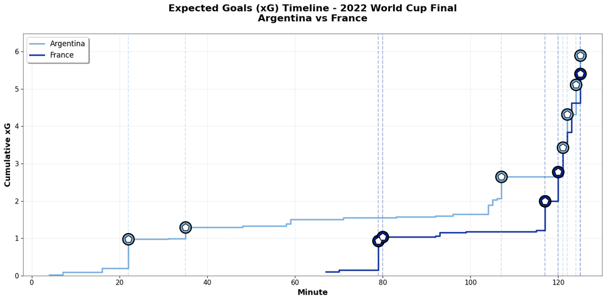

```python
# Visualizing

fig, ax = plt.subplots(figsize=(14, 7), facecolor='white')
ax.set_facecolor('white')

# Team colors
argentina_color = '#75AADB'  # Light blue (Argentina)
france_color = '#002395'      # Navy blue (France)

# Plot step lines for cumulative xG
ax.step(
    argentina_shots['minute'],
    argentina_shots['cum_xg'],
    where='post',
    label='Argentina',
    linewidth=2.5,
    color=argentina_color,
    alpha=0.9
)

ax.step(
    france_shots['minute'],
    france_shots['cum_xg'],
    where='post',
    label='France',
    linewidth=2.5,
    color=france_color,
    alpha=0.9
)

# Mark goals with football markers (using large circles to simulate footballs)
argentina_goals = argentina_shots[argentina_shots['goal']]
france_goals = france_shots[france_shots['goal']]

# Argentina goals
ax.scatter(
    argentina_goals['minute'],
    argentina_goals['cum_xg'],
    s=350,
    color=argentina_color,
    edgecolors='black',
    linewidth=2,
    zorder=5,
    marker='o'
)

# Add white pattern to simulate football
for _, goal in argentina_goals.iterrows():
    ax.scatter(
        goal['minute'],
        goal['cum_xg'],
        s=150,
        color='white',
        edgecolors='black',
        linewidth=1,
        zorder=6,
        marker='p'
    )

# France goals
ax.scatter(
    france_goals['minute'],
    france_goals['cum_xg'],
    s=350,
    color=france_color,
    edgecolors='black',
    linewidth=2,
    zorder=5,
    marker='o'
)

# Add white pattern to simulate football
for _, goal in france_goals.iterrows():
    ax.scatter(
        goal['minute'],
        goal['cum_xg'],
        s=150,
        color='white',
        edgecolors='black',
        linewidth=1,
        zorder=6,
        marker='p'
    )

# Add vertical dashed lines for goals
for minute in argentina_goals['minute']:
    ax.axvline(minute, linestyle='--', alpha=0.3, color=argentina_color, linewidth=1.5)

for minute in france_goals['minute']:
    ax.axvline(minute, linestyle='--', alpha=0.3, color=france_color, linewidth=1.5)

# Styling
ax.set_xlabel('Minute', fontsize=13, weight='bold')
ax.set_ylabel('Cumulative xG', fontsize=13, weight='bold')
ax.set_title(
    'Expected Goals (xG) Timeline - 2022 World Cup Final\nArgentina vs France',
    fontsize=16,
    weight='bold',
    pad=20
)

# Legend
ax.legend(fontsize=12, loc='upper left', frameon=True, fancybox=True, shadow=True)

# Grid
ax.grid(alpha=0.3, color='gray', linestyle='--', linewidth=0.5)
ax.tick_params(labelsize=11)

# Set spine colors
for spine in ax.spines.values():
    spine.set_edgecolor('gray')
    spine.set_linewidth(1)

# Set x-axis limits
ax.set_xlim(-2, max(argentina_shots['minute'].max(), france_shots['minute'].max()) + 5)
ax.set_ylim(0, max(argentina_shots['cum_xg'].max(), france_shots['cum_xg'].max()) * 1.1)

plt.tight_layout()
plt.show()
```

### Team and Players Statistics Across The Entire 2022 World Cup Tournament

```python
#team and player statistics across the entire 2022 World Cup tournament

import pandas as pd
import matplotlib.pyplot as plt
import numpy as np
from matplotlib.patches import Rectangle
import matplotlib.patches as mpatches
```

```python
# Load All World Cup 2022 Matches

print("Loading all World Cup 2022 matches...")

# Get all match IDs from the tournament
all_match_ids = matches['match_id'].tolist()

print(f"Total matches in dataset: {len(all_match_ids)}")

# Load events for all matches (this may take a moment)
all_events = []
for i, match_id in enumerate(all_match_ids):
    print(f"Loading match {i+1}/{len(all_match_ids)}...", end='\r')
    match_events = sb.events(match_id=match_id)
    all_events.append(match_events)

# Combine all events
wc_events = pd.concat(all_events, ignore_index=True)
print(f"\nTotal events loaded: {len(wc_events)}")
```

```
Loading all World Cup 2022 matches...
Total matches in dataset: 64
Loading match 64/64...
Total events loaded: 234652
```

```python
#TEAM STATISTICS

print("\nCalculating team statistics...")

# Initialize team stats dictionary
team_stats = []

for team in wc_events['team'].unique():
    team_events = wc_events[wc_events['team'] == team]

    # Possession (based on pass count as proxy)
    total_passes = len(team_events[team_events['type'] == 'Pass'])

    # Shots
    shots = team_events[team_events['type'] == 'Shot']
    total_shots = len(shots)
    shots_on_target = len(shots[shots['shot_outcome'].isin(['Goal', 'Saved'])])

    # xG
    total_xg = shots['shot_statsbomb_xg'].sum()

    # Goals
    goals = len(shots[shots['shot_outcome'] == 'Goal'])

    # Assists
    assists = len(team_events[team_events['pass_goal_assist'] == True])

    # Pass completion
    successful_passes = len(team_events[
        (team_events['type'] == 'Pass') &
        (team_events['pass_outcome'].isna())
    ])
    pass_completion = (successful_passes / total_passes * 100) if total_passes > 0 else 0

    # Tackles and Interceptions
    tackles = len(team_events[team_events['type'] == 'Tackle'])
    interceptions = len(team_events[team_events['type'] == 'Interception'])

    team_stats.append({
        'Team': team,
        'Passes': total_passes,
        'Pass %': pass_completion,
        'Shots': total_shots,
        'Shots on Target': shots_on_target,
        'xG': total_xg,
        'Goals': goals,
        'Assists': assists,
        'Tackles': tackles,
        'Interceptions': interceptions
    })

teams_df = pd.DataFrame(team_stats)
```

```
Calculating team statistics...
```

```python
teams_df.head()
```

|  | Team | Passes | Pass % | Shots | Shots on Target | xG | Goals | Assists | Tackles | Interceptions |
| --- | --- | --- | --- | --- | --- | --- | --- | --- | --- | --- |
| 0 | Serbia | 1503 | 78.908849 | 32 | 9 | 3.090398 | 5 | 4 | 0 | 25 |
| 1 | Switzerland | 2035 | 82.211302 | 37 | 13 | 6.090516 | 5 | 4 | 0 | 43 |
| 2 | Argentina | 4615 | 85.352113 | 110 | 56 | 20.988443 | 23 | 8 | 0 | 70 |
| 3 | Australia | 1707 | 74.458114 | 26 | 8 | 1.578172 | 3 | 2 | 0 | 42 |
| 4 | Denmark | 1928 | 83.661826 | 35 | 11 | 3.192257 | 1 | 0 | 0 | 33 |

```python
# PLAYER STATISTICS

print("Calculating player statistics...")

player_stats = []

for player in wc_events['player'].dropna().unique():
    player_events = wc_events[wc_events['player'] == player]
    team = player_events['team'].iloc[0] if len(player_events) > 0 else 'Unknown'

    # Shots
    shots = player_events[player_events['type'] == 'Shot']
    total_shots = len(shots)

    # xG
    total_xg = shots['shot_statsbomb_xg'].sum()

    # Goals
    goals = len(shots[shots['shot_outcome'] == 'Goal'])

    # Assists
    assists = len(player_events[player_events['pass_goal_assist'] == True])

    # Passes
    passes = player_events[player_events['type'] == 'Pass']
    total_passes = len(passes)
    successful_passes = len(passes[passes['pass_outcome'].isna()])
    pass_completion = (successful_passes / total_passes * 100) if total_passes > 0 else 0

    # Key passes (passes leading to shots)
    key_passes = len(player_events[player_events['pass_shot_assist'] == True])

    # Dribbles
    dribbles = len(player_events[player_events['type'] == 'Dribble'])

    player_stats.append({
        'Player': player,
        'Team': team,
        'Goals': goals,
        'Assists': assists,
        'xG': total_xg,
        'Shots': total_shots,
        'Passes': total_passes,
        'Pass %': pass_completion,
        'Key Passes': key_passes,
        'Dribbles': dribbles
    })

players_df = pd.DataFrame(player_stats)

print("Data preparation complete!")
```

```
Calculating player statistics...
Data preparation complete!
```

```python
players_df.head(5)
```

|  | Player | Team | Goals | Assists | xG | Shots | Passes | Pass % | Key Passes | Dribbles |
| --- | --- | --- | --- | --- | --- | --- | --- | --- | --- | --- |
| 0 | Breel-Donald Embolo | Switzerland | 2 | 0 | 2.391197 | 6 | 66 | 75.757576 | 2 | 4 |
| 1 | Remo Freuler | Switzerland | 1 | 0 | 0.544795 | 3 | 149 | 84.563758 | 0 | 4 |
| 2 | Silvan Widmer | Switzerland | 0 | 1 | 0.051174 | 1 | 164 | 77.439024 | 1 | 0 |
| 3 | Fabian Lukas Schär | Switzerland | 0 | 0 | 0.103673 | 2 | 80 | 80.000000 | 0 | 0 |
| 4 | Djibril Sow | Switzerland | 0 | 1 | 0.150380 | 2 | 96 | 90.625000 | 2 | 1 |

```python
# ============================================
# TOP 5 TEAMS - OVERALL PERFORMANCE
# ============================================

# Prepare data using teams_df dataframe
top_teams = (teams_df[['Team', 'Shots', 'xG', 'Goals']]
             .sort_values('Goals', ascending=False)
             .head(5)
             .reset_index(drop=True))

# Style the table
styled_teams = (top_teams.style
    .format({'xG': '{:.2f}'})  # Format xG to 2 decimals
    .bar(subset=['Shots'], color='#4e79a7')  # Blue bars for shots
    .bar(subset=['Goals'], color='#e15759')  # Red bars for goals
    .background_gradient(subset=['xG'], cmap='Greens')  # Green gradient for xG
    .set_caption('Top 5 Teams by xG - 2022 FIFA World Cup')
    .set_table_styles([
        {'selector': 'caption', 'props': [('font-size', '16px'), ('font-weight', 'bold')]}
    ]))

display(styled_teams)
```

Top 5 Teams by xG - 2022 FIFA World Cup

|  | Team | Shots | xG | Goals |
| --- | --- | --- | --- | --- |
| 0 | Argentina | 110 | 20.99 | 23 |
| 1 | France | 106 | 14.96 | 18 |
| 2 | Croatia | 87 | 13.17 | 15 |
| 3 | Netherlands | 48 | 8.91 | 13 |
| 4 | England | 63 | 8.74 | 13 |

- The top 5 teams all scored more goals than their xG predicted, showing that top ranked teams possess superior finishing quality that exceeds statistical expectations.
- The table also reveals Argentina's tournament dominance, leading in shot volume (110), quality (20.99 xG) and goals (23).
- France demonstrated superior finishing efficiency, scoring 18 goals from just 14.96 expected goals.

```python
# ============================================
# TOP 10 PASSERS
# ============================================

# Prepare data (filter players with min 50 passes)
top_passers = (players_df[players_df['Passes'] >= 50]
               [['Player', 'Team', 'Passes', 'Pass %']]
               .sort_values('Passes', ascending=False)
               .head(10)
               .reset_index(drop=True))

# Style the table
styled_passers = (top_passers.style
    .format({'Pass %': '{:.1f}%'})  # Format pass % to 1 decimal
    .bar(subset=['Passes'], color='#4e79a7')  # Blue bars for passes
    .background_gradient(subset=['Pass %'], cmap='Greens')  # Green gradient for accuracy
    .set_caption('Top 10 Passers (min. 50 passes)')
    .set_table_styles([
        {'selector': 'caption', 'props': [('font-size', '16px'), ('font-weight', 'bold')]}
    ]))

display(styled_passers)
```

Top 10 Passers (min. 50 passes)

|  | Player | Team | Passes | Pass % |
| --- | --- | --- | --- | --- |
| 0 | Rodrigo Hernández Cascante | Spain | 677 | 94.8% |
| 1 | Nicolás Hernán Otamendi | Argentina | 562 | 93.4% |
| 2 | Rodrigo Javier De Paul | Argentina | 562 | 84.3% |
| 3 | Luka Modrić | Croatia | 547 | 84.3% |
| 4 | Marcelo Brozović | Croatia | 528 | 89.2% |
| 5 | Joško Gvardiol | Croatia | 508 | 90.9% |
| 6 | Enzo Fernandez | Argentina | 469 | 88.5% |
| 7 | Aurélien Djani Tchouaméni | France | 468 | 92.1% |
| 8 | Mateo Kovačić | Croatia | 454 | 91.4% |
| 9 | Dejan Lovren | Croatia | 452 | 89.6% |

```python
# ============================================
# TOP 10 ASSISTS BY PLAYERS
# ============================================

top_assists = (players_df[['Player', 'Team', 'Assists', 'Key Passes']]
               .sort_values('Assists', ascending=False)
               .head(10)
               .reset_index(drop=True))

# Style the table
styled_assists = (top_assists.style
    .bar(subset=['Assists'], color='#e15759')  # Red bars for assists
    .bar(subset=['Key Passes'], color='#f28e2b')  # Orange bars for key passes
    .set_caption('Top 10 Assist Providers')
    .set_table_styles([
        {'selector': 'caption', 'props': [('font-size', '16px'), ('font-weight', 'bold')]}
    ]))

display(styled_assists)
```

Top 10 Assist Providers

|  | Player | Team | Assists | Key Passes |
| --- | --- | --- | --- | --- |
| 0 | Lionel Andrés Messi Cuccittini | Argentina | 3 | 16 |
| 1 | Harry Kane | England | 3 | 2 |
| 2 | Bruno Miguel Borges Fernandes | Portugal | 3 | 6 |
| 3 | Antoine Griezmann | France | 3 | 17 |
| 4 | Ivan Perišić | Croatia | 3 | 6 |
| 5 | Dušan Tadić | Serbia | 2 | 7 |
| 6 | Mislav Oršić | Croatia | 2 | 3 |
| 7 | João Félix Sequeira | Portugal | 2 | 1 |
| 8 | Raphaël Adelino José Guerreiro | Portugal | 2 | 4 |
| 9 | Vinícius José Paixão de Oliveira Júnior | Brazil | 2 | 6 |

### AVG POSSESSION & PASSING PER MATCH

```python
# ============================================
# AVG POSSESSION & PASSING PER MATCH
# ============================================

# Calculate per-match statistics
team_match_stats = []

for team in wc_events['team'].unique():
    team_events = wc_events[wc_events['team'] == team]

    # Get all matches this team played
    team_match_ids = team_events['match_id'].unique()

    for match_id in team_match_ids:
        # Get all events from this specific match
        match_events = wc_events[wc_events['match_id'] == match_id]

        # Team's passes in this match
        team_passes_in_match = len(match_events[
            (match_events['team'] == team) &
            (match_events['type'] == 'Pass')
        ])

        # Total passes in this match (both teams)
        total_passes_in_match = len(match_events[match_events['type'] == 'Pass'])

        # Possession proxy for this match
        possession_pct = (team_passes_in_match / total_passes_in_match * 100) if total_passes_in_match > 0 else 0

        # Pass accuracy for this match
        team_match_passes = match_events[
            (match_events['team'] == team) &
            (match_events['type'] == 'Pass')
        ]
        successful = len(team_match_passes[team_match_passes['pass_outcome'].isna()])
        accuracy = (successful / team_passes_in_match * 100) if team_passes_in_match > 0 else 0

        team_match_stats.append({
            'Team': team,
            'Match_ID': match_id,
            'Possession %': possession_pct,
            'Passes': team_passes_in_match,
            'Pass Accuracy %': accuracy
        })

# Convert to DataFrame
match_stats_df = pd.DataFrame(team_match_stats)

# Calculate averages per team
team_averages = match_stats_df.groupby('Team').agg({
    'Possession %': 'mean',
    'Passes': 'mean',
    'Pass Accuracy %': 'mean',
    'Match_ID': 'count'
}).reset_index()

team_averages.rename(columns={
    'Possession %': 'Avg Possession %',
    'Passes': 'Avg Passes',
    'Pass Accuracy %': 'Avg Pass Accuracy %',
    'Match_ID': 'Matches Played'
}, inplace=True)

# Top 10 by possession
top_possession = (team_averages[['Team', 'Avg Possession %', 'Avg Passes', 'Avg Pass Accuracy %', 'Matches Played']]
                          .sort_values('Avg Possession %', ascending=False)
                          .head(10)
                          .reset_index(drop=True))

# Style the table
styled_possession = (top_possession.style
    .format({
        'Avg Possession %': '{:.1f}%',
        'Avg Passes': '{:.1f}',
        'Avg Pass Accuracy %': '{:.1f}%'
    })
    .bar(subset=['Avg Possession %'], color='#59a14f')
    .bar(subset=['Avg Passes'], color='#4e79a7')
    .background_gradient(subset=['Avg Pass Accuracy %'], cmap='Greens')
    .set_caption('Top 10 Teams - Possession & Passes')
    .set_table_styles([
        {'selector': 'caption', 'props': [('font-size', '16px'), ('font-weight', 'bold')]}
    ]))

display(styled_possession)
```

Top 10 Teams - Possession & Passes

|  | Team | Avg Possession % | Avg Passes | Avg Pass Accuracy % | Matches Played |
| --- | --- | --- | --- | --- | --- |
| 0 | Spain | 75.3% | 978.5 | 90.1% | 4 |
| 1 | England | 63.1% | 647.6 | 86.3% | 5 |
| 2 | Portugal | 60.9% | 625.8 | 84.8% | 5 |
| 3 | Denmark | 59.7% | 642.7 | 83.7% | 3 |
| 4 | Germany | 58.9% | 654.3 | 84.4% | 3 |
| 5 | Argentina | 57.7% | 659.3 | 84.9% | 7 |
| 6 | Belgium | 56.8% | 622.3 | 85.5% | 3 |
| 7 | Brazil | 56.0% | 639.2 | 86.8% | 5 |
| 8 | Croatia | 54.3% | 644.4 | 84.0% | 7 |
| 9 | Mexico | 53.9% | 478.3 | 77.0% | 3 |

### When Do Goals Happen Most? Scoring Patterns Across Match Periods.

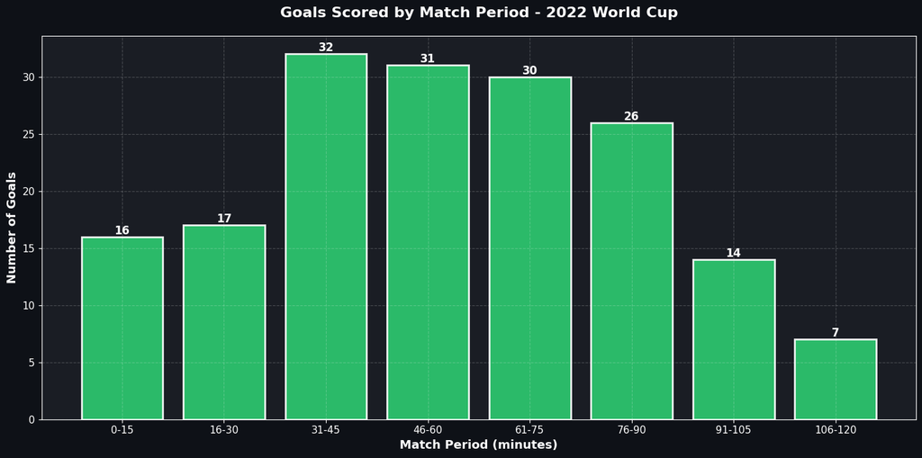

```python
# ============================================
# TOURNAMENT-WIDE: GOALS BY MATCH MINUTE
# ============================================

def goals_by_minute_tournament(events_df):
    """When are goals scored in the tournament"""
    goals = events_df[
        (events_df['type'] == 'Shot') &
        (events_df['shot_outcome'] == 'Goal')
    ].copy()

    # Bin by 15-minute periods
    goals['period_bin'] = pd.cut(goals['minute'],
                                 bins=[0, 15, 30, 45, 60, 75, 90, 105, 120],
                                 labels=['0-15', '16-30', '31-45', '46-60',
                                        '61-75', '76-90', '91-105', '106-120'])

    period_counts = goals['period_bin'].value_counts().sort_index()

    fig, ax = plt.subplots(figsize=(14, 7), facecolor='#0e1117')
    ax.set_facecolor('#1a1d24')

    bars = ax.bar(period_counts.index, period_counts.values,
                  color='#2ecc71', edgecolor='white', linewidth=2, alpha=0.9)

    # Highlight values on bars
    for bar in bars:
        height = bar.get_height()
        ax.text(bar.get_x() + bar.get_width()/2., height,
               f'{int(height)}', ha='center', va='bottom',
               fontsize=12, weight='bold', color='white')

    ax.set_title('Goals Scored by Match Period - 2022 World Cup',
                 fontsize=16, weight='bold', color='white', pad=20)
    ax.set_xlabel('Match Period (minutes)', fontsize=13, color='white', weight='bold')
    ax.set_ylabel('Number of Goals', fontsize=13, color='white', weight='bold')
    ax.tick_params(colors='white', labelsize=11)
    ax.grid(alpha=0.2, color='white', linestyle='--')

    for spine in ax.spines.values():
        spine.set_edgecolor('white')

    plt.tight_layout()
    return fig

fig_goals_time = goals_by_minute_tournament(wc_events)
plt.show()
```

Key Insights:

- Goals peak just before halftime (31–45 minutes), suggesting teams increase attacking intensity as the first half draws to a close.
- The early second half (46–75 minutes) remains highly productive for goals scored, reflecting tactical adjustments and increased tempo after halftime.
- Goal output drops sharply in extra time, indicating fatigue, conservative play, and higher risk management in knockout scenarios.

### Which Teams Had the Best Conversion Rate?

```
============================================================
TOP 5 TEAMS - CONVERSION EFFICIENCY
============================================================
Portugal        | xG:  7.31 | Goals: 12 | Diff: +4.69
England         | xG:  8.74 | Goals: 13 | Diff: +4.26
Netherlands     | xG:  8.91 | Goals: 13 | Diff: +4.09
France          | xG: 14.96 | Goals: 18 | Diff: +3.04
Argentina       | xG: 20.99 | Goals: 23 | Diff: +2.01
============================================================
```

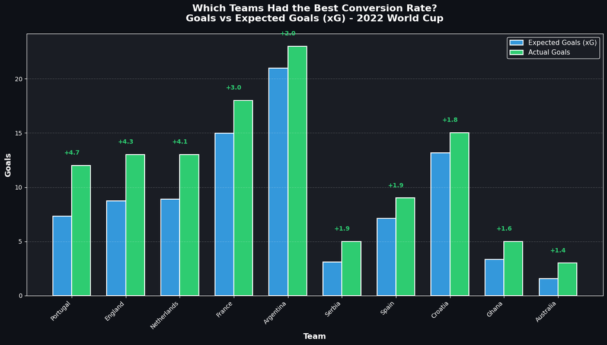

```python
# ============================================
# 9. WHICH TEAMS HAD THE BEST CONVERSION RATE?
#    (Goals vs xG Performance)
# ============================================

def conversion_efficiency_analysis(events_df):
    """Analyze which teams overperformed/underperformed their xG"""

    team_conversion = []

    for team in events_df['team'].unique():
        team_shots = events_df[
            (events_df['team'] == team) &
            (events_df['type'] == 'Shot')
        ]

        total_xg = team_shots['shot_statsbomb_xg'].sum()
        actual_goals = len(team_shots[team_shots['shot_outcome'] == 'Goal'])

        conversion_diff = actual_goals - total_xg
        conversion_rate = (actual_goals / len(team_shots) * 100) if len(team_shots) > 0 else 0

        team_conversion.append({
            'Team': team,
            'xG': total_xg,
            'Goals': actual_goals,
            'Difference': conversion_diff,
            'Conversion %': conversion_rate
        })

    conversion_df = pd.DataFrame(team_conversion).sort_values('Difference', ascending=False)

    # Visualize top 10
    top_10 = conversion_df.head(10)

    fig, ax = plt.subplots(figsize=(14, 8), facecolor='#0e1117')
    ax.set_facecolor('#1a1d24')

    x = np.arange(len(top_10))
    width = 0.35

    bars1 = ax.bar(x - width/2, top_10['xG'], width,
                   label='Expected Goals (xG)', color='#3498db',
                   edgecolor='white', linewidth=1.5)
    bars2 = ax.bar(x + width/2, top_10['Goals'], width,
                   label='Actual Goals', color='#2ecc71',
                   edgecolor='white', linewidth=1.5)

    # Add difference annotations
    for i, (xg, goals, diff) in enumerate(zip(top_10['xG'], top_10['Goals'], top_10['Difference'])):
        color = '#2ecc71' if diff > 0 else '#e74c3c'
        ax.text(i, max(xg, goals) + 1, f'{diff:+.1f}',
               ha='center', fontsize=10, weight='bold', color=color)

    ax.set_xlabel('Team', fontsize=13, color='white', weight='bold')
    ax.set_ylabel('Goals', fontsize=13, color='white', weight='bold')
    ax.set_title('Which Teams Had the Best Conversion Rate?\nGoals vs Expected Goals (xG) - 2022 World Cup',
                 fontsize=16, weight='bold', color='white', pad=20)
    ax.set_xticks(x)
    ax.set_xticklabels(top_10['Team'], rotation=45, ha='right', color='white')
    ax.legend(fontsize=11, facecolor='#1a1d24', edgecolor='white', labelcolor='white')
    ax.tick_params(colors='white')
    ax.grid(alpha=0.2, color='white', linestyle='--', axis='y')

    for spine in ax.spines.values():
        spine.set_edgecolor('white')

    plt.tight_layout()

    print("\n" + "="*60)
    print("TOP 5 TEAMS - CONVERSION EFFICIENCY")
    print("="*60)
    for idx, row in conversion_df.head(5).iterrows():
        print(f"{row['Team']:15} | xG: {row['xG']:5.2f} | Goals: {row['Goals']:2.0f} | Diff: {row['Difference']:+5.2f}")
    print("="*60)

    return fig

fig_conversion = conversion_efficiency_analysis(wc_events)
plt.show()
```

Key Insights:

- Portugal show the strongest overperformance relative to xG, indicating exceptional finishing efficiency compared to chance quality. England is 2nd with xG of +4.3.
- Argentina and France both exceed their xG totals, combining high chance creation with clinical conversion at the tournament’s highest level.
- Several teams outperform xG by smaller margins, suggesting effective finishing but less consistent chance volume or shot quality.

### Where Do Most Goals Come From?

Shot Location Heatmap for All Goals

```
============================================================
GOAL LOCATION STATISTICS
============================================================
Total Goals: 195

By Type:
type_category
Open Play    150
Penalty       43
Free Kick      2
Name: count, dtype: int64

Average Goal Distance from Goal: 10.8 yards
============================================================
```

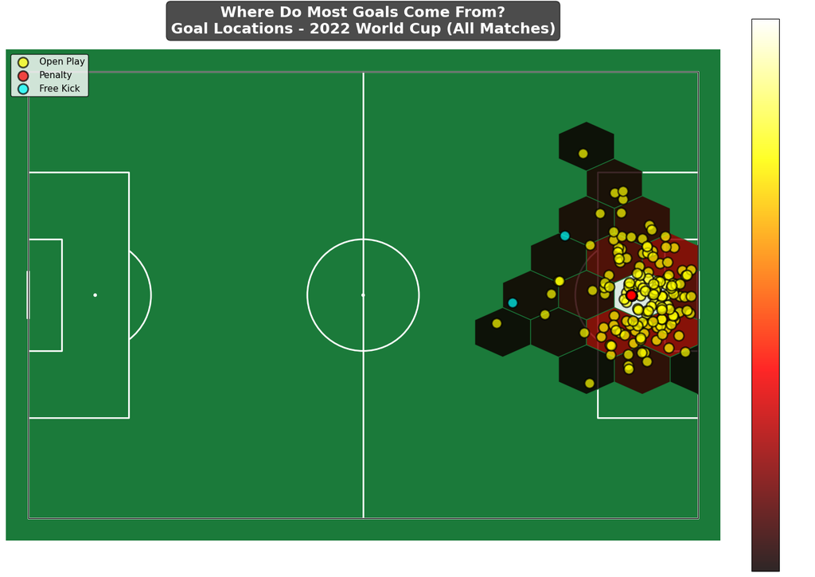

```python
# ============================================
# 10. WHERE DO MOST GOALS COME FROM?
#     (Shot Location Heatmap for All Goals)
# ============================================

def goal_location_heatmap(events_df):
    """Analyze from where goals were scored in the tournament"""

    goals = events_df[
        (events_df['type'] == 'Shot') &
        (events_df['shot_outcome'] == 'Goal')
    ].copy()

    goals['x'] = goals['location'].str[0]
    goals['y'] = goals['location'].str[1]

    # Categorize by type
    goals['type_category'] = 'Open Play'
    goals.loc[goals['shot_type'] == 'Penalty', 'type_category'] = 'Penalty'
    goals.loc[goals['shot_type'] == 'Free Kick', 'type_category'] = 'Free Kick'

    # Create visualization
    pitch = Pitch(pitch_type="statsbomb", pitch_color="#1b7a3a",
                  line_color="white", linewidth=2)
    fig, ax = plt.subplots(figsize=(14, 10), facecolor='white')
    pitch.draw(ax=ax)

    # Hexbin for goal density
    hexmap = pitch.hexbin(goals['x'], goals['y'],
                          gridsize=12, cmap='hot',
                          edgecolors='#1b7a3a', linewidth=1,
                          ax=ax, alpha=0.85, mincnt=1)

    # Add colorbar
    cbar = plt.colorbar(hexmap, ax=ax, fraction=0.046, pad=0.04)
    cbar.set_label('Number of Goals', color='white', fontsize=12, weight='bold')
    cbar.ax.tick_params(colors='white')

    # Add goal markers
    colors = {'Open Play': 'yellow', 'Penalty': 'red', 'Free Kick': 'cyan'}
    for goal_type, color in colors.items():
        type_goals = goals[goals['type_category'] == goal_type]
        if len(type_goals) > 0:
            pitch.scatter(type_goals['x'], type_goals['y'],
                         s=150, color=color, edgecolors='black',
                         linewidth=2, alpha=0.7, label=goal_type, ax=ax, zorder=3)

    ax.legend(fontsize=11, loc='upper left', facecolor='white', edgecolor='black')
    ax.set_title('Where Do Most Goals Come From?\nGoal Locations - 2022 World Cup (All Matches)',
                 fontsize=18, weight='bold', color='white', pad=20,
                 bbox=dict(boxstyle='round', facecolor='black', alpha=0.7))

    plt.tight_layout()

    # Statistics
    print("\n" + "="*60)
    print("GOAL LOCATION STATISTICS")
    print("="*60)
    print(f"Total Goals: {len(goals)}")
    print(f"\nBy Type:")
    print(goals['type_category'].value_counts())
    print(f"\nAverage Goal Distance from Goal: {(120 - goals['x']).mean():.1f} yards")
    print("="*60)

    return fig

fig_goal_locations = goal_location_heatmap(wc_events)
plt.show()
```

- The overwhelming majority of goals were scored from inside the penalty area from open play, particularly in central positions near the six-yard box.
- Penalties and free kicks constituted a substantial minority of total goals, highlighting set piece proficiency as a critical tournament success factor.

### How Effective Were Set Pieces?

(Goals from Set Pieces vs Open Play)

```
============================================================
SET PIECE EFFECTIVENESS
============================================================
Total Goals: 195

Breakdown:
Open Play       | 150 goals ( 76.9%)
Penalty         |  43 goals ( 22.1%)
Free Kick       |   2 goals (  1.0%)
============================================================
```

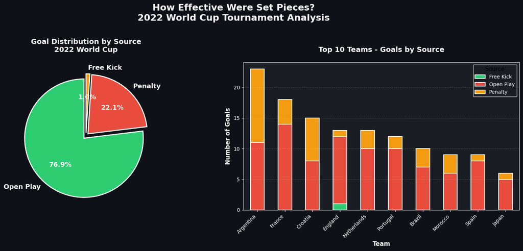

```python
# ============================================
# 12. HOW EFFECTIVE WERE SET PIECES?
#     (Goals from Set Pieces vs Open Play)
# ============================================

def set_piece_effectiveness(events_df):
    """Analyze goals from set pieces vs open play"""

    goals = events_df[
        (events_df['type'] == 'Shot') &
        (events_df['shot_outcome'] == 'Goal')
    ].copy()

    # Categorize goal types
    goals['source'] = 'Open Play'
    goals.loc[goals['shot_type'] == 'Penalty', 'source'] = 'Penalty'
    goals.loc[goals['shot_type'] == 'Free Kick', 'source'] = 'Free Kick'



    # Create visualization - pie chart and bar chart
    fig, axes = plt.subplots(1, 2, figsize=(16, 7), facecolor='#0e1117')

    # Pie chart
    source_counts = goals['source'].value_counts()
    colors = ['#2ecc71', '#e74c3c', '#f39c12']
    explode = (0.05, 0.05, 0.05)

    axes[0].pie(source_counts.values, labels=source_counts.index,
               autopct='%1.1f%%', startangle=90, colors=colors,
               explode=explode, textprops={'fontsize': 13, 'weight': 'bold', 'color': 'white'},
               wedgeprops={'edgecolor': 'white', 'linewidth': 2})
    axes[0].set_title('Goal Distribution by Source\n2022 World Cup',
                     fontsize=14, weight='bold', color='white', pad=20)
    axes[0].set_facecolor('#1a1d24')

    # Bar chart by team
    team_goal_sources = goals.groupby(['team', 'source']).size().unstack(fill_value=0)
    team_totals = team_goal_sources.sum(axis=1).sort_values(ascending=False).head(10)
    top_teams_goals = team_goal_sources.loc[team_totals.index]

    top_teams_goals.plot(kind='bar', stacked=True, ax=axes[1],
                         color=colors, edgecolor='white', linewidth=1.5)

    axes[1].set_title('Top 10 Teams - Goals by Source',
                     fontsize=14, weight='bold', color='white', pad=20)
    axes[1].set_xlabel('Team', fontsize=12, color='white', weight='bold')
    axes[1].set_ylabel('Number of Goals', fontsize=12, color='white', weight='bold')
    axes[1].tick_params(colors='white')
    axes[1].set_xticklabels(axes[1].get_xticklabels(), rotation=45, ha='right', color='white')
    axes[1].legend(title='Source', fontsize=10, title_fontsize=11,
                  facecolor='#1a1d24', edgecolor='white', labelcolor='white')
    axes[1].grid(alpha=0.2, color='white', linestyle='--', axis='y')
    axes[1].set_facecolor('#1a1d24')

    for spine in axes[1].spines.values():
        spine.set_edgecolor('white')

    fig.suptitle('How Effective Were Set Pieces?\n2022 World Cup Tournament Analysis',
                 fontsize=18, weight='bold', color='white', y=0.98)

    plt.tight_layout(rect=[0, 0, 1, 0.96])

    print("\n" + "="*60)
    print("SET PIECE EFFECTIVENESS")
    print("="*60)
    print(f"Total Goals: {len(goals)}")
    print(f"\nBreakdown:")
    for source, count in source_counts.items():
        percentage = (count / len(goals) * 100)
        print(f"{source:15} | {count:3} goals ({percentage:5.1f}%)")
    print("="*60)

    return fig

fig_set_pieces = set_piece_effectiveness(wc_events)
plt.show()
```

- Nearly 77% of World Cup goals came from open play
- Penalties accounted for 22.1% of all goals, making penalty-area incursions and defensive discipline critical tournament factors.

Uzoh C. Hillary

LinkedIn : http://www.linkedin.com/in/hillaryuzoh

Github : https://github.com/Uzo-Hill

Email : uzohhillary@gmail.com